# MATH-509: Lab 07

**Daniel Carter**

## Getting Started

Follow the instructions below to copy this notebook and to perform some initial setup.

1. Copy this notebook by selecting `File > Save a copy in Drive`.
2. A new window should open for the copied notebook. Move the new notebook to your course folder in Google Drive by selecting `File > Move` and then selecting the desired folder.
3. Update the name of the notebook by removing "Copy of" and replacing "Username" with your actual username.
4. Update the first cell in the notebook by replacing "Student Name" with your actual name.
5. Mount your Google Drive by running the cell below and accepting the prompts you are presented with.

```python
from google.colab import drive
drive.mount('/content/drive')
```

## Import Statements

Run the cell below to import the NumPy and Matplotlib packages.

```python
import numpy as np
import matplotlib.pyplot as plt
np.set_printoptions(suppress=True)
```

# Problem 1 - Descriptive Statistics

Let $X$ be a discrete random variable with probability mass function shown below.

| $x$ | 1 | 2 | 4 | 8 | 16 | 32 | 64 |
| --- | --- | --- | --- | --- | --- | --- | --- |
| $p(x)$ | 0.08 | 0.13 | 0.30 | 0.24 | 0.16 | 0.06 | 0.03 |

## Part 1.A

Use the cell below to perform the following tasks:

1. Create an array to store the values of $X$.
2. Create an array to store the probabilities provide by $p(x)$.
3. Use NumPy operations to calculate $E[X]$.
4. Use NumPy operations to calculate $\textrm{Var}[X]$.
5. Print $E[X]$ rounded to 2 decimal places.
6. Print $\textrm{Var}[X]$ rounded to 2 decimal places.

```python
x = np.array([1,2,4,8,16,32,64])
p = np.array([.08,.13,.30,.24,.16,.06,.03])
EX = np.dot(x,p)
x_squared = x**2
EX2 = np.dot(x_squared, p)
VarX = EX2 - EX**2

print(f'EX: {np.round(EX, 2)}')
print(f'VarX: {np.round(VarX,2)}')
```

```
EX: 9.86
VarX: 148.82
```

## Part 1.B

Define a new random variable $\large Y = \textrm{ln}(X)$. Use the cell below to perform the following tasks.

1. Create an array to store the possible values for $Y$.
2. Use NumPy operations to calculate $E[Y]$.
3. Use NumPy operations to calculate $\textrm{Var}[Y]$.
4. Print $E[Y]$ rounded to 2 decimal places.
5. Print $\textrm{Var}[Y]$ rounded to 2 decimal places.

```python
Y = np.log(x)
EY = np.dot(Y, p)
y_squared = Y**2
EY2 = np.dot(y_squared, p)
VarY = EY2-EY**2
print(f'EY: {np.round(EY, 2)}')
print(f'VarY: {np.round(VarY,2)}')
```

```
EY: 1.78
VarY: 0.97
```

## Part 1.C

Fill in the blanks below to create a bar chart to visualize the distribution of $X$.

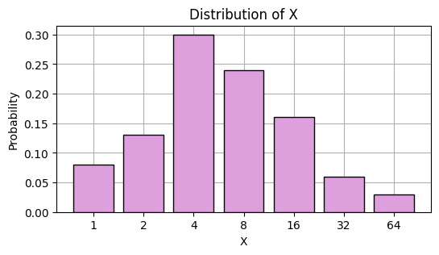

```python
plt.figure(figsize=[6,3])
plt.bar(x.astype(str), p, color='plum', edgecolor='black', zorder=2)
plt.title('Distribution of X')
plt.xlabel('X')
plt.ylabel('Probability')
plt.grid()
plt.show()
```

# Problem 2 - Probability Calculations

Two arrays named `x` and `p` are provided in the cell below. These arrays are intended to represent the distribution for a random variable $X$. If you run the cell below, you will see the possible values of $X$ and will also see that the values in `p` sum to (approximately) 1.

You may change the names of the arrays `p` and `x`, if you wish, but leave the rest of the contents of the cell as they are and then run the cell.

```python
x = 10 * np.arange(1,101).astype(int)
p = 0.0157736754 * (0.99) ** (x/10 - 1)
print(x, '\n')
print(p.sum())
```

```
[  10   20   30   40   50   60   70   80   90  100  110  120  130  140
  150  160  170  180  190  200  210  220  230  240  250  260  270  280
  290  300  310  320  330  340  350  360  370  380  390  400  410  420
  430  440  450  460  470  480  490  500  510  520  530  540  550  560
  570  580  590  600  610  620  630  640  650  660  670  680  690  700
  710  720  730  740  750  760  770  780  790  800  810  820  830  840
  850  860  870  880  890  900  910  920  930  940  950  960  970  980
  990 1000]

1.000000006285405
```

## Part 2.A

Use the cell below to calculate each of the probabilities listed below. Store the results in variables.

Print each of the proabilities calculated above in the order in which they are listed and rounded to 4 decimal places.

```python
p1 = p[x >= 800].sum()
p2 = p[x <= 300].sum()
p3 =  p[(x >= 250) & (x <= 500)].sum()

print(f'Probability 1: {np.round(p1,4)}')
print(f'Probability 2: {np.round(p2,4)}')
print(f'Probability 3: {np.round(p3,4)}')
```

```
Probability 1: 0.1357
Probability 2: 0.4106
Probability 3: 0.285
```

## Part 2.B

A **conditional probability** is a probability that is calculated under the assumption that a certain condition has been met. Let $A$ and $B$ be events. The expression $P[A ~|~ B]$ is read as "probability of $A$ given $B$", and is calculated using the formula below.

$$\large P[A ~|~ B] = \frac{P[A \textrm{ and } B]}{P[B]}$$

Calculate the two conditional probability shown below. You can (and should) reuse variables that you created in Part 2.A.

- $P [X \leq 300 ~|~ X \leq 500]$
- $P [X \geq 250 ~|~ X \leq 500]$

Print both conditional probabilities in the order in which they are listed and rounded to 4 decimal places.

```python
cp1 = (p[(x <= 300) & (x <= 500)].sum())/(p[x <= 500].sum())
cp2 = p3/(p[x <= 500].sum())

print(f'Condintional Probability 1: {np.round(cp1,4)}')
print(f'Condintional Probability 2: {np.round(cp2,4)}')
```

```
Condintional Probability 1: 0.659
Condintional Probability 2: 0.4574
```

# Problem 3 - Maximum of 3 Dice

Suppose that three ten-sided dice are rolled. The faces of each dice are numbered using integers 1 - 10. Define a random variable $M$ to be equal to the largest value rolled. For example, if the rolls are 3, 7, 4, then $m=7$. We will explore the distribution of $M$ using simulation.

## Part 3.A

We will start by creating a sample of observations of $M$ Use the cell below to complete the following tasks:

1. Use NumPy to set a seed of 1.
2. Use `np.random.choice()` to create a 2D array with size `(10_000, 3)`, with entries randomly sampled from the integers 1 - 10.
3. Use the `np.max()` function to find the maximum of each row in the array from step 2. You will need to set `axis=1` to find the row maximums. This will be our sample of obsersevations of $M$.
4. Print the shape of the last array found. This should be `(10000,)`.

```python
np.random.seed(1)
m = np.random.choice(range(1,11),size=(10000,3))
M = np.max(m,axis=1)
print(M.shape)
```

```
(10000,)
```

## Part 3.B

We will now estimate the distribution of $M$.

1. Use `np.unique()` to determine the unique values and the counts of values appearing in the sample.
2. Then calculate the proportions of observations in the sample with each value.
3. Print the proportion array, rounded to 2 decimal places.

```python
values,counts = np.unique(M, return_counts=True)
props = counts/counts.sum()
print(f'Proportion array: {np.round(props,2)}')
```

```
Proportion array: [0.   0.01 0.02 0.04 0.06 0.09 0.13 0.17 0.21 0.27]
```

## Part 3.C

Fill in the blanks below to create a proportional bar chart to visualize the approximate distribution of $M$.

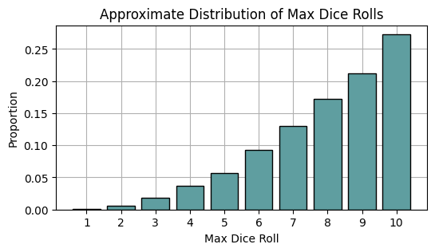

```python
plt.figure(figsize=[6,3])
plt.bar(values.astype(str), props, color='cadetblue', edgecolor='black', zorder=2)
plt.title('Approximate Distribution of Max Dice Rolls')
plt.xlabel('Max Dice Roll')
plt.ylabel('Proportion')
plt.grid()
plt.show()
```

## Part 3.D

Use the sample generated in Part 3.A to estimate $E[M]$ and $SD[M]$. Print both values rounded to 3 decimal places.

```python
sample_mean = np.round(np.mean(M),3)
sample_std = np.round(np.std(M, ddof=1),3)

print(f'Sample Mean: {sample_mean}')
print(f'Sample STD: {sample_std}')
```

```
Sample Mean: 7.984
Sample STD: 1.914
```

# Problem 4 - Defective Widgets

Widget is a term sometimes used to refer to a generic manufactured good. Suppose a factory produces widgets. They sell the widgets to retailers in batches of 1000. It is known that 1 in every 200 widgets is defective. In other words, an individual widget has a 0.005 probability of being defective. Let $D$ be a random variable representing the number of defective widgets in a batch of 1000. In this problem, you will use simulation to approximate a distribution for $D$.

## Part 4.A

Use the cell below to complete the following tasks:

1. Use NumPy to set a seed of 1.
2. Use `np.random.choice()` to create a 2D array with size `(10_000, 1000)` with entries randomly sampled from the integers `[0, 1]` according to the following probabilities: `p=[0.995, 0.005]`. Each row in this array will represent a single batch of 1000 widgets. The entries containing "1" will represent defective widgets.
3. Use the `np.sum()` function to find the sum of each row in the array from step 2. You will need to set `axis=1` to find the row sums. This will be our sample of obsersevations of $D$.
4. Print the shape of the last array found. This should be `(10000,)`.

```python
np.random.seed(1)
d = np.random.choice(range(0,2),size=(10000,1000),p=[.995,.005])
D = np.sum(d,axis=1)
print(D.shape)
```

```
(10000,)
```

## Part 4.B

We will now estimate the distribution.

1. Use `np.unique()` to determine the unique values and the counts of values appearing in the sample.
2. Then calculate the proportions of observations in the sample with each value.
3. Print the proportion array, rounded to 4 decimal places.

```python
values,counts = np.unique(D,return_counts=True)
props = counts/counts.sum()
print(f'Proportion: {np.round(props,4)}')
```

```
Proportion: [0.0079 0.0323 0.0831 0.1424 0.1767 0.1786 0.146  0.1022 0.0622 0.0363
 0.0202 0.0079 0.0027 0.001  0.0002 0.0003]
```

## Part 4.C

Fill in the blanks below to create a proportional bar chart to visualize the approximate distribution of $D$.

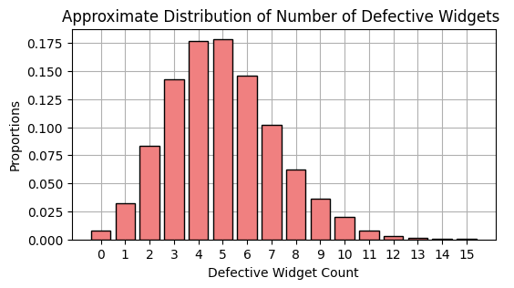

```python
plt.figure(figsize=[6,3])
plt.bar(values.astype(str), props, color='lightcoral', edgecolor='black', zorder=2)
plt.title('Approximate Distribution of Number of Defective Widgets ')
plt.xlabel('Defective Widget Count')
plt.ylabel('Proportions')
plt.grid()
plt.show()
```

## Part 4.D

Use the sample simulated in Part 4.A to estimate the probabilities mentioned below. Print each probability rounded to 4 decimal places and in the the order listed.

- $P[D < 3]$
- $P[D \geq 5]$
- $P[4 \leq D \leq 6]$

```python
p1 = np.mean(D < 3)
p2 = np.mean(D >= 5)
E = (D >= 4) & (D <= 6)
p3 = np.mean(E)
print(f'P1: {np.round(p1,4)}')
print(f'P2: {np.round(p2,4)}')
print(f'P3: {np.round(p3,4)}')
```

```
P1: 0.1233
P2: 0.5576
P3: 0.5013
```

# Problem 5 - Ride Share Service

A random variable is said to followin a **Poisson** distribution if its support consists of all non-negative integers and its PMF is given by the following formula for some fixed parameter value $\lambda$.

$$p(x) = \frac{e^{-\lambda} \lambda ^ x}{x!}$$

Let $R$ be a random variable that represents the number of requests recieved by a ride share service in a certain city during a specific one-hour period. Suppose that $R$ follows a Poission distribution with $\lambda = 50$. We will use simulation to explore the random variable $R$.

We will start by generating a sample of 10,000 observations of $R$. NumPy provides a function `np.random.poisson()` for generating samples of the Poission distribution. We use that function in the cell below to generate our sample for $R$. We also print the first 20 observations in the sample. Run this cell as-is.

```python
np.random.seed(1)
requests = np.random.poisson(50, size=10000)
print(requests[:20])
```

```
[48 41 43 48 48 48 41 46 38 39 67 54 54 45 39 61 45 43 50 51]
```

## Part 5.A

Use the sample provided to estimate the expected value of $E[R]$ and the standard deviation $SD[R]$ of the number of ride requests during an hour. Print both values rounded to 2 decimal places.

```python
mean = np.mean(requests)
std = np.std(requests,ddof=1)
print(f'Estimated Expected Value: {np.round(mean,2)}')
print(f'Estimated Standard Deviation: {np.round(std,2)}')
```

```
Estimated Expected Value: 49.96
Estimated Standard Deviation: 6.96
```

## Part 5.B

Use the sample provided to estimate the probabilities mentioned below. Print each probability rounded to 4 decimal places and in the the order listed.

- $P[R \leq 40]$
- $P[R \geq 50]$

```python
p1 = np.mean(requests<=40)
p2 = np.mean(requests>=50)
print(f'P1: {np.round(p1,4)}')
print(f'P2: {np.round(p2,4)}')
```

```
P1: 0.0835
P2: 0.5202
```

## Part 5.C

Use `np.percentile()` to calculate the 1st percentile and the 99th percentile of the number of rides requested in the simulated sample. Print both percentiles.

```python
p01 = np.percentile(requests,q=1)
p99 = np.percentile(requests,q=99)

print(f'First percentile: {p01}')
print(f'Ninety-nineth percentile: {p99}')
```

```
First percentile: 34.0
Ninety-nineth percentile: 66.0
```

## Part 5.D

Suppose that the service uses a surge pricing model in which the cost $C$ for a ride is based on the number of requests during the previous hour, and is calculated using the following formula:

$$C = 2 \cdot (1.04) ^ R$$

Complete the following tasks in the cell below.

1. Use NumPy operations to apply the cost formula to the values in the `requests` sample. This creates a sample of costs.
2. Calculate the mean and standard deviation of the costs.
3. Print the mean and standard deviation of the cost sample rounded to 2 decimal places.

```python
C = 2*(1.04**requests)
mean = np.mean(C)
std = np.std(C)
print(f'Mean: {np.round(mean,2)}')
print(f'Standard Deviation: {np.round(std,2)}')
```

```
Mean: 14.74
Standard Deviation: 4.15
```

## Part 5.E

- $P[C > 10]$
- $P[C > 20]$

```python
p1 = np.mean(C>10)
p2 = np.mean(C>20)
print(f'P1:{np.round(p1,2)}')
print(f'P2:{np.round(p2,2)}')
```

```
P1:0.89
P2:0.11
```

# Problem 6 - Selection in Genetic Algorithms

**Genetic algorithms** are a classical family of A.I. algorithms in which many possible candidate solutionsfor a problem are generated, and then selection, mutation, and reproduction processes are applied to "evolve" the solutions over time. We won't disucss all of the details here, we will take a look at how the selection process is performed.

When performing selection for a genetic algorithm, each candidate solution is assigned a **fitness score**. Each candidate is then assigned a probability of being selected. This probability is proportional to the candidate's fitness score. We then draw a sample of the desired size from the population of solutions. The sample is created according the to fitness-based probabilities and without replacement.

You will explore this selection process in this example. The code cell is used to create and print fitness scores for a population of 100 candidate solutions. The fitness scores are randomly assigned for the sake of this example, and range from 0 to 50. Run this cell as-is.

```python
np.random.seed(1)
fitness = np.random.choice(range(51), size=100)
print(fitness)
```

```
[37 43 12  8  9 11  5 15  0 16  1 12  7 45  6 25 50 20 37 18 20 11 42 28
 29 14 50  4 23 23 41 49 30 32 22 13 41  9  7 22  1  0 17  8 24 13 47 42
  8 30  7  3  6 21 49  3  4 24 49 43 12 26 16 45 41 18 15  0  4 25 47 34
 23  7 26 25 40 22  9  3 39 23 36 27 37 19 38  8 32 34 10 23 15 47 23 25
  7 28 10 46]
```

## Part 6.A

Calculate selection probabilities for each of the 100 candidate solutions. This is accomplished by dividing each fitness value by the total fitness for all 100 observations. Use NumPy operations rather than loops or list comprehensions.

Print the selection probabilities for the first 10 candidates, rounded to 4 decimal places.

```python
probs = fitness/fitness.sum()
print(np.round(probs[:10],4))
```

```
[0.0164 0.0191 0.0053 0.0036 0.004  0.0049 0.0022 0.0067 0.     0.0071]
```

## Part 6.B

Perfrom the following tasks in the cell below:

```python
np.random.seed(1)
indices = np.random.choice(range(0,100),size=20,p=probs,replace=False)
print(indices)
```

```
[45 74  0 31 18 13 22 34 42 58 71 23 88  1 70 59 17 85 98 36]
```

## Part 6.C

Select the fitness values of the selected individuals by passing the sample of indices to the `fitness` array. Print the fitness values of the selected individuals.

```python
selected_fitnesses = fitness[indices]
print(selected_fitnesses)
```

```
[13 26 37 49 37 45 42 22 17 49 34 28 32 43 47 43 20 19 10 41]
```

## Part 6.D

We will now confirm that this selection process did favor individuals with higher fitness scores. In the cell below, calculate and print the following values:

- The average fitness for all 100 solutions.
- The average fitness for the 20 selected solutions.

```python
print(f'Average fitness for all 100 solutions: {np.mean(fitness)}')
print(f'Average fitness for the 20 selected solutions: {np.mean(selected_fitnesses)}')
```

```
Average fitness for all 100 solutions: 22.51
Average fitness for the 20 selected solutions: 32.7
```

# Submission Instructions

1. The cell below will generate an HTML render of your notebook within the same Google Drive folder in which you stored this notebook. Adjust the path for your notebook in the cell below as needed.
2. Restart your notebook and run it from start to finish.
3. If the notebook executes without error, download the HTML export of the notebook and then upload it to Canvas. Make sure to carefully review the contents of the HTML export to ensure that everything is displayed correctly.
4. Click on "Share" in the upper-right corner of this notebook. Then select "Anyone with the link" from dropdown. Click "Copy Link" and paste the copied link as a comment in your submission on Canvas.

```python
%%capture
import time
time.sleep(30)
!jupyter nbconvert --to html /content/drive/MyDrive/MATH_509/Lab_07_dcarter8.ipynb
```